# A mzungu attends a Ugandan Gusaba

2018-08-27

It was no surprise to any of us when my brother-in-law got engaged to Faith. They were together for, like, forever. Faith became a member our family long ago. James and Faith are really cool people — when you get to be old like me, there are people you wish you would hang out with more often, but just don’t. You don’t because being old means you spend your days doing inane daily errands, and you end up too tired or busy or too far away or whatever. James and Faith are definitely in that subset of people I know that I wish we could hang out with more.

James is from Maine. Faith is of Rwandan ancestry, and grew up in Uganda with her family. James and Faith met in California. It blows my mind how many little random coincidences had to line up perfectly for the two of them to even find each other.

Faith’s family still lives in Uganda, and so it was only fitting that she have a Ugandan-style ceremony in her home country. Fortunately for us, our family was invited to attend!

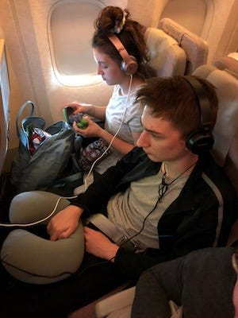

The kids settle in for 20 hours of flight time.

### Getting to Uganda

Flights to Uganda are unsurprisingly long. We opted to fly through Dubai — so it was almost 13 hours from Boston to Dubai, and then another 5.5 hours from Dubai to Uganda’s main airport, Entebbe (the Dubai airport is probably worthy of its own blog post). The Gusaba ceremony was to take place at a resort hotel in Entebbe the day after we arrived, so we relaxed by the pool and got a good night’s sleep before the big day.

A gusaba is an “introduction ceremony.” Normally, it would happen days or even weeks before the formal wedding that often takes place in a church. The introduction ceremony is where the groom’s family asks the bride’s family for permission to marry — in Rwandan tradition, a wedding represents a marriage of two families as well as two people.

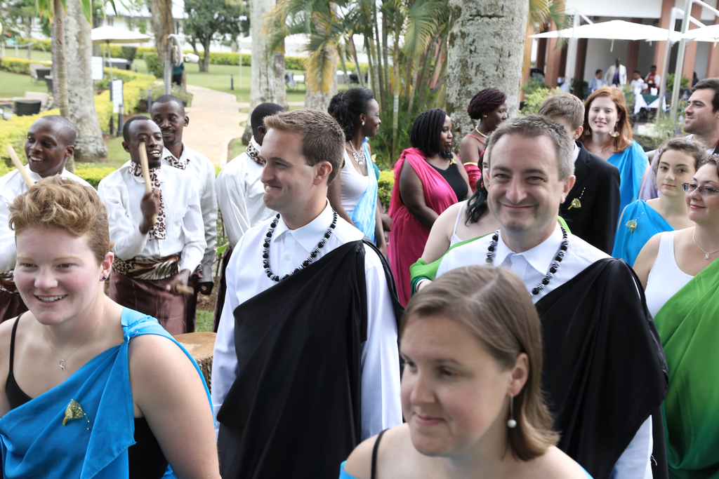

The groom’s family shows up to crash the party. James (the groom) is the guy on the left. People keep telling us we look alike. ¯_(ツ)_/¯

At this point, the two families were seated separately, in tents across from each other and a large gap between them. Each family was led by an elder representative during the proceedings. There was also a gentleman emceeing the event. The entire ceremony was conducted in the native language of the bride. There are 57 different languages spoken in Uganda, and in our case, the bride’s family and tribe spoke Kinyarwandan, a language commonly spoken in Rwanda and the Ugandan region bordering Rwanda. Fortunately, most Ugandans speak English quite well (in part because Uganda was once a British territory), and our hosts and friends graciously kept us informed what was happening during the ceremony.

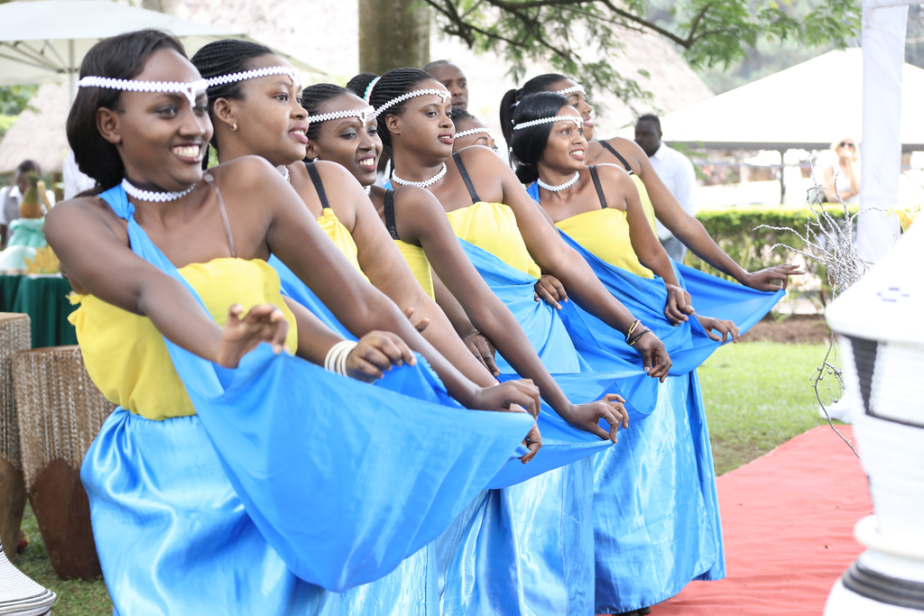

Some of the entertainers at the Gusaba.

After the groom’s family was seated, the bride’s family’s representative asked something like (paraphrasing, obviously) “What are you doing here? We’re having our own little private party — we didn’t invite you, go away!” To which our representative feigned shock that we weren’t being treated as proper guests (how rude!), and that the bride’s family should show some decency and accomodate us. At this point, the bride’s representative acquiesced and invited us to stay, eat, and enjoy some of the entertainment.

We were treated to a feast, dancing, singing, and drumming. After being entertained for a bit, our representative piped up (again, paraphrasing): “Actually, there’s a reason we’re here — we forgot to mention it earlier. There’s a gentleman in our party who would very much like to marry a young woman from your family. Her name is Faith.”

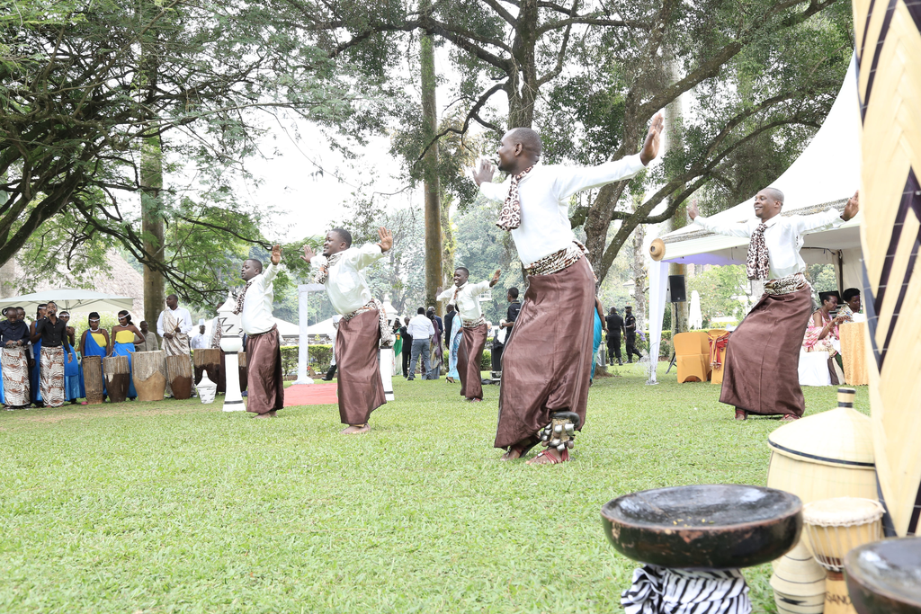

The dancing and drumming was spectacular. It’s really unfortunate that you can’t capture it with a photo.

The bride’s family conferred among themselves, then responded “Nope, there’s nobody by that name here. Faith? Haven’t heard of her! Sorry!”

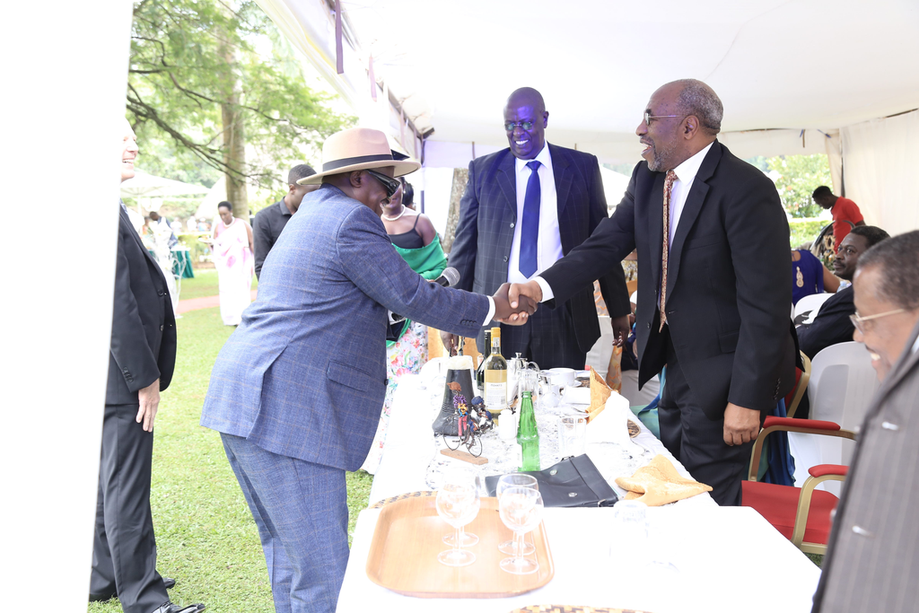

The man in the hat on the left is Frank, and he represented the groom’s family in the negotiations. The man on the right represents the bride. The gentleman in the tie standing behind them both is the bride’s father, Dr. Paul Kagwa.

Ouch. Denied. I sure hope James got her name right. Maybe they were just messing with us? Fortunately our representative was persistent. After another song, he again spoke up and inquired about Faith.

The bride’s family once again conferred and responded to us. “Okay, fine, whatever. We’ll go ask around. Perhaps there is someone here by that name, but honestly we still don’t know what you guys are talking about. Are you certain that’s her name?”

Fortunately there was a lot of entertainment and singing between these exchanges, and we were again treated to some more singing before the bride’s family got back to us. “Okay, today is your lucky day!” (I’m really paraphrasing a lot here, I apologize) “we have found not only one Faith, but several, and you can have your pick!”

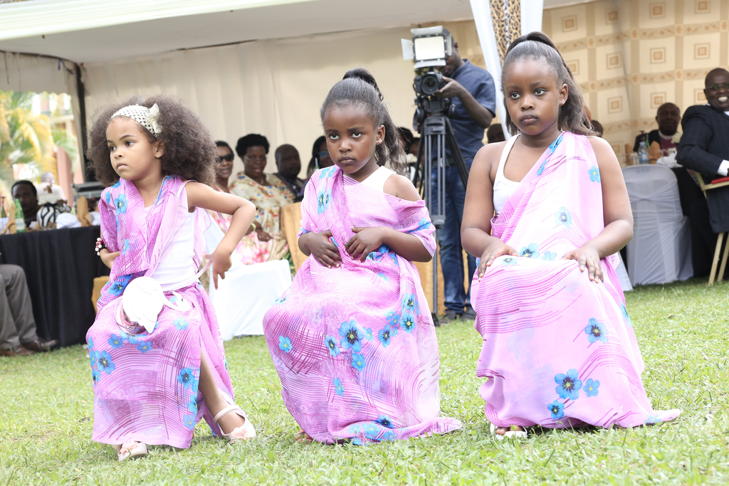

Nice try, guys. None of these are Faith.

At this point the bride’s family tried to pass off some young girls as the one James wanted to marry. Sometimes at gusabas, there are several rounds of this — older girls, elderly women, etc. We were running on a tighter-than-usual schedule, so they only tried to trick us one time.

Our representative responded “These are not Faith — our Faith is a beautiful young lady, these are girls!” (or something like that, I’m imagining, I really wish I spoke Kinyarwandan) “bring us Faith!”

“Okay okay we’ll keep looking — but we’re telling you these are the only Faiths we could find.” Back to more dancing, singing, drumming, excellent food, etc.

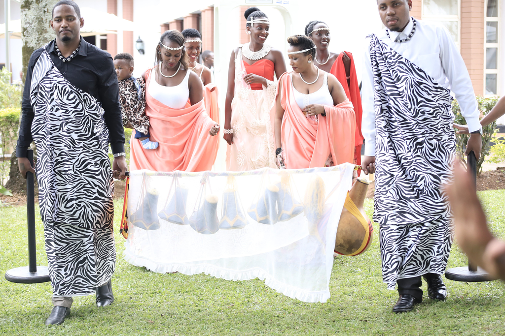

The bride, Faith, is in the center wearing red

### Faith Arrives

Finally, Faith made her grand entrance, escorted by several cousins from her family (Side note: “cousins” in east Africa aren’t really the same thing as cousins in the United States. Here, one might call anyone from their tribe their “cousin.” Sometimes they even call “what-we-call cousins” their brothers and sisters. This is partly because extended families are so important in their culture. This tripped us up a few times when we asked family members how they were related to Faith).

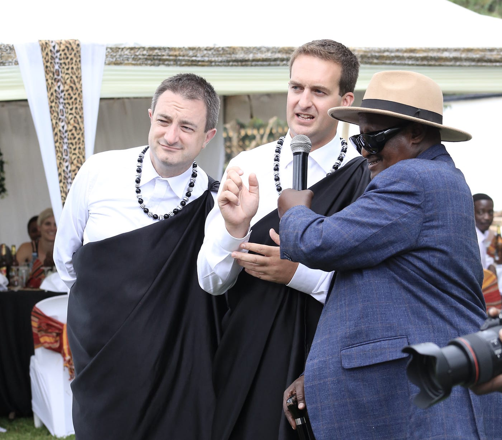

James is confirming which woman, exactly, is the one that he is inquiring about. It looks like he had to think carefully about it.

“Yes! This is the Faith we were talking about!” our mediator said. “Our James would like to marry her.” At this point the two families started to negotiate for Faith’s dowery.

At this point I really wish I spoke the language, because I’m sure there was some great trash-talking and humorous awkwardness (“Eight cows! She’s not worth eight cows — no more than five honestly!”). At some point, somehow, the two families came to an agreement.

### Getting Past the Nephew

It was still not over for James, though. When Faith arrived, she went with her entourage to a small hut-like area separate from both families. The people she arrived with were guarding her. If James was to marry Faith, he had to get past those family members, and they looked pretty mean.

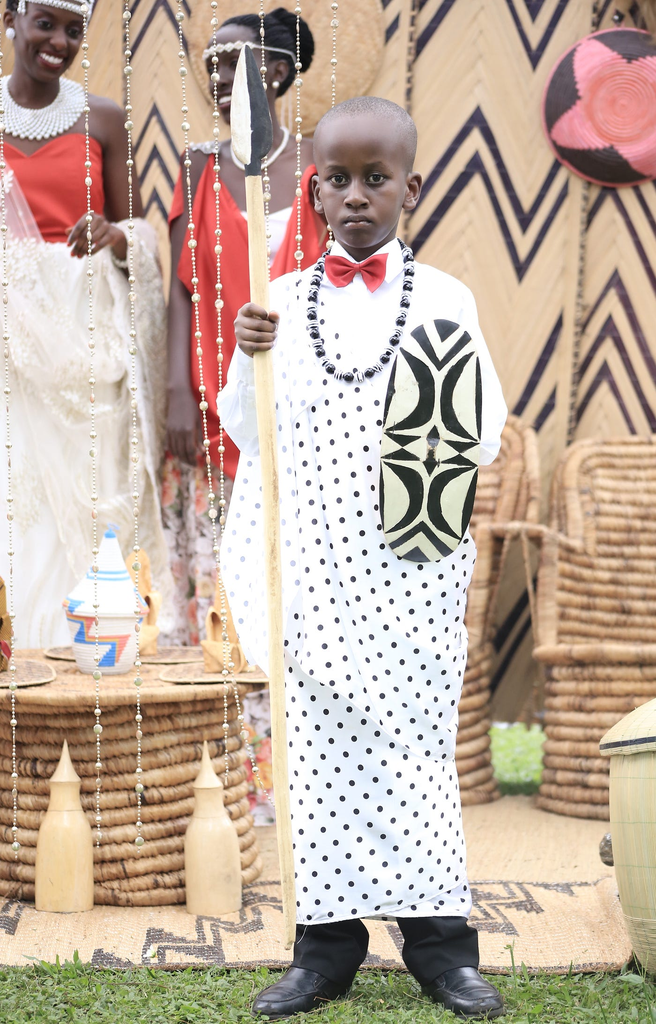

Nathan was serious and he was having none of this.

Fiercest and meanest among them was Faith’s seven year old nephew, Nathan. James’ plan was to bribe Nathan. First he tried his credit card. Nathan wasn’t interested in that, so James tried some candy. That didn’t do the trick, either. Finally James slipped him twenty bucks. We were in!

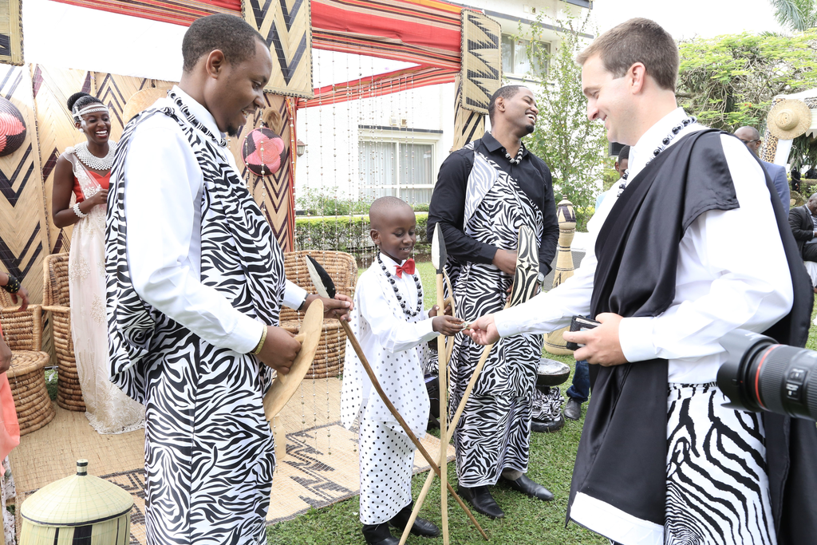

Cash. Always go with cash.

At this point James had to present his own gift to the bride, and this was pretty similar to western tradition — he got down on one knee, presented her with a ring, and she said yes!

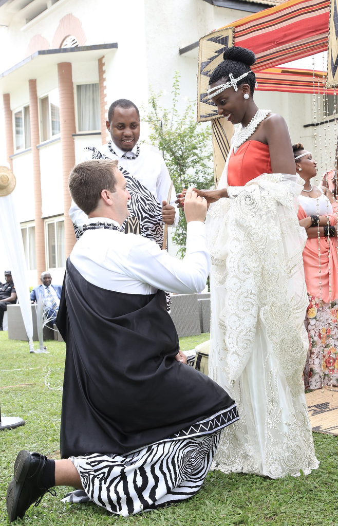

She said yes!

At this point, there’s more celebration and singing. Our particular gusaba was interesting because the Prime Minister of Uganda happened to be in attendance (coincidentally, the bride’s father and the honorable Prime Minister Dr. Ruhakana Ruganda are friends and former colleagues), and he said a few words at the end.

[This work is licensed under a [Creative Commons Attribution-NonCommercial-NoDerivatives 4.0 International License](http://creativecommons.org/licenses/by-nc-nd/4.0/) .](http://creativecommons.org/licenses/by-nc-nd/4.0/)